# COMP 20230: Assignment 1

## Submission Details

1. **Detail**: This assignment is worth 40% of the overall mark for COMP20230. It should be uploaded to the Brightspcae by 2330pm on Friday 26th March 2021
2. **Submission**: A report (PDF) contains codes and analysis of your solution. In addition, the codes should be submitted in Jupiter notebooks
3. **Evaluation Criteria**: Logic 50%, Code 25% and Creativity of report 25%

## Brief

The following is the assignment brief:

1. Write an algorithm to compute the factorial of a positive integer n.
2. For different values of n, implement your algorithm using two approaches: iterative and recursive (tail and non-tail recursions). For each case, plot running time as a function of n and compare the achieved results.
3. Use one of the sequences obtained from task 2 as an input for search algorithms. Implement with two methods from: linear search, iterative binary and recursive binary.
4. For each approach, compute the best and worst running times. Give some examples by plotting the running time as a function of n.
5. Use curve-fitting algorithms to find the equation of the running times obtained from Tasks 2-4. See the attached example.

## Submission Details Per Brightspace:

Please note that the submission is **an ipython notebook with explanations in markdown**.

Please save images of the graphs you output and include in your submission a zipped folder with the jupyter notebook and images.

This is because the graphs output by the notebook will differ depending on the machine, OS etc, and we may not see the same image you do when we run the notebook to grade. You only need to add "plt.savefig('file_nameXX.png')" at the end of the cell where you plot.

```python
####-----------------------------------------------------###
```

# COMP20230: Assignment 1 Begin

## Part 1: Factorial Functions

In this section we will define the factorial functions, check their complexity

```python
####-----------------------------------------------------###
import time
import numpy as np
from matplotlib import pyplot as plt
from sklearn.linear_model import LinearRegression
from scipy.optimize import curve_fit

#!pip install memory_profiler
#from memory_profiler import profile

####-----------------------------------------------------###
```

## Iterative Factorial

### Algorithm

And iterative algorithm is implemented. 'Naive factorial'

#### Naive Factorial

This is the standard iterative approach. The algorithm is:

Step 0: Assuming function is passed $n \in \mathbb{N} \cup \{0\}$

Step 1: Set $F_0:=1$.

Step 2: while n>1, $F_1:=F_0*(n_0), n_1:=n_0 - 1$

Step 3: Return the factorial.

In other words:

1. Set the Factorial as 1
2. While n > 1, define the factorial as the existing value by multiplied by where in the loop it is. Then take 1 from n.
3. Return the factorial at the end.

### Pseudocode

#### iterative_factorial

```
def iterative_factorial(n):
    INPUT: n, a non-negative integer
    OUTPUT: n! an integer
```

```
fact=1

while n > 1
    fact*=n
    n-=1

return fact
```

## Iterative Factorial Function

```python
def iterative_factorial(nonneg_integer):
    """A naive function to get the factorial of a number n. There is an assumption n>=0

    This is implemented using an iterative approach.
    """

    #Set the factorial as 1 to cover base case
    factorial=1

    while nonneg_integer>1:
        factorial*=nonneg_integer
        nonneg_integer-=1

    return factorial
```

### Complexity analysis

#### iterative_factorial

1. We can see that initiallty we have one operation defining factorial as 1 Total
2. We run through the for loop n times, and in each time we perform a multiplication of the current value of the factorial, and the current index in the loop, and define it to be the factorial. Total of n operations.
3. This will perform in $\mathcal{O}(n)$. Scales linearly.

##### More mathematically:

```
L1    factorial=1
L2
L3    while nonneg_integer>1:
L4        factorial*=nonneg_integer
L5        nonneg_integer-=1
```

L1 = 1 Operation L3: Cond L4 = 2 operations L5:2 Operations

The while loop will repeat n times, 4 operations in the loop. $T(f(n)) \propto 4n = \mathcal{O}(n)$

#### Graphing the complexity of iterative_factorial

### Function to return the average runtime of C iterations of the factorial function from 1 to n

```python
def return_runtime(number_of_time_to_run,highest_factorials_to_compute):
    """
    Runs the factorial function a number of times and returns a dictionary with the value for each run

    Input: Number of times to run and highest factorial: both must be positive>=1
    Output: Dictionary
    """

    #Empty Dictionary
    run_time_amounts={}

    #For each run less than the highest
    for run in range(1,number_of_time_to_run):

        #Create an empty time array to store the results for this run
        time_array=[]

        #wipe these variables
        time_start=0
        time_end=0


        #Go through each value up to highest number to compute
        for fact_count in range(1,highest_factorials_to_compute):

            #Start Timer
            time_start=time.perf_counter_ns()

            #Naive Factorial
            iterative_factorial(fact_count)

            #End timer
            time_end=time.perf_counter_ns()

            #Get delta
            time_delta=time_end-time_start

            #Save to array
            time_array+=[time_delta]

        #Add to dictionary. Key is the number of the run
        run_time_amounts[run]=time_array

    return run_time_amounts
```

### Given a dictionary of runtimes, return the mean of each run.

```python
def get_mean_runtime(dict_to_mean):
    """Get the mean runtimes

    Input: Dictionary
    Output: Array
    """

    average_runtime_array=np.nanmean(list(dict_to_mean.values()),axis=0)

    return average_runtime_array
```

### Plot the runtimes Add a linear regression plot.

We use a linear regression model based on the Complexity Analysis. Will later use curve_fitting to validate

```python
def plot_runtimes(average_time_array,title,x_axis_title,y_axis_title,include_best_fit_line):
    """Plot the runtimes

    Input: Average time array, Titles, Whether to include the line of best fit
    Returned: Plot
    """

    #Get the rescapes x and y values for the regression model
    X = np.array(range(1,len(average_time_array)+1)).reshape(-1,1)
    Y = np.array(average_time_array).reshape(-1,1)

    #Regression Fit from SKLearn
    reg = LinearRegression().fit(X, Y)

    #Regression score
    display(reg.score(X, Y))

    #Plot the X and Y arrays
    plt.plot(X,Y,label='Iterative Fact Avg Runtime (ns)')

    #Include the line of best fit
    if include_best_fit_line:
        model=LinearRegression().fit(X, Y)
        model_pred=model.predict(X)
        model_m_val=model.coef_
        model_c_val=model.intercept_
        name=f"""Iter Line of best Fit: y={model_m_val}x+{model_c_val}"""

        #Overlay the plot with the regression line; predict the line of best fit
        plt.plot(X, model_pred,label=name)

    #Set the formatting stuff
    plt.title(title)
    plt.ylabel(y_axis_title)
    plt.xlabel(x_axis_title)

    plt.legend()

    #Save in the local directory
    plt.savefig('Iterative_Factorial_Function_Solo.png')

    return
```

### Combine the functions

```python
def analyse_linear_regression(number_of_time_to_run,highest_factorials_to_compute,title,x_axis_title,y_axis_title,include_best_fit_line):
    """Return the graph"""

    runtime=return_runtime(number_of_time_to_run,highest_factorials_to_compute)
    mean_array=get_mean_runtime(runtime)
    graph=plot_runtimes(mean_array,title,x_axis_title,y_axis_title,include_best_fit_line)

    return
```

### Graph to help highlight if my time complexity of linearity is right.

```
0.9038969752403383
```

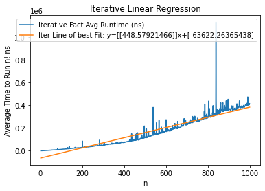

```python
analyse_linear_regression(number_of_time_to_run=100,highest_factorials_to_compute=1000,title='Iterative Linear Regression',x_axis_title='n',y_axis_title='Average Time to Run n! ns',include_best_fit_line=True)
```

## Part 1 Continued: Recursive Functions

## Recursive Factorial

### Algorithm

Two recursive algorithms are implemented. 'Non Tail factorial' and 'Tail Factorial'.

#### Factorial Not Tail

This is the 'easy' recursive approach. The algorithm is:

Step 0: Assuming function is passed $n \in \mathbb{N} \cup \{0\}$

Step 1: If $n=1$ then return 1, otherwise return $n * f(n-1)$

In other words:

1. The base case is 1
2. So long as the entry to the recursive function isn't 1, return the value of the current value multipled by the function(value-1)
3. When it hits base cases passes up value.

### Pseudocode

#### recursive_factorial_not_tail(x)

```
def n_factorial(n):
    INPUT: n, a non-negative integer
    OUTPUT: n*n_factorial(n-1) -> n! after calls
```

```
if n=1
    return 1

else
    return n * n_factorial(n-1)
```

#### Factorial Tail

This is the 'trickier' recursive approach. The algorithm is:

Step 0: Assuming function is passed $n \in \mathbb{N} \cup \{0\}$ and also an accumulator $a \in \mathbb{N}$

Step 1: If $n=1$ then return the accumulator, otherwise call the function again with $f(n-1,n*accumulator)$

Step 2: Start by falling f(x,1)

In other words:

1. The base case is 1. The accumulator collects the results of the factorial so far.
2. So long as the entry to the recursive function isn't 1, enter the function again.
3. When it hits base case it outputs the result of the accumulator

### Pseudocode

#### recursive_factorial_tail(x)

```
def n_factorial(n,a):
    INPUT: n, a non-negative integer a=1 when initially calling (the accumulator)
    OUTPUT: n_factorial(n-1,n*accumulator) -> n! after calls
```

```
if n=1
    return a

else
    return n_factorial(n-1,n*a)
```

```python
def recursive_factorial_not_tail(x):
    """Returns x!

    Requires x>=1 and uses recursion"""

    #base case
    if x==1:
        return 1

    # x<>0 need to progress down to n0
    else:
        return x*recursive_factorial_not_tail(x-1)
```

```python
def recursive_factorial_tail_wrap(x):
    """A function to call the recursive factorial tail.

    Return x!"""

    def recursive_factorial_tail(x,accumulator):
        """Returns x!

        Requires x>=0 and uses recursion. TRacks history of results via accumulator"""

        #base case
        if x==1:
            return accumulator

        # x<>0 need to progress down to n0
        else:
            return recursive_factorial_tail(x-1,x*accumulator)


    return recursive_factorial_tail(x,1)
```

### Complexity analysis

#### recursive_factorial_not_tail

1. We do $a$ operations in each activation.
2. We will this function n times implying n total operations.
3. This will perform in $\mathcal{O}(an)=\mathcal{O}(n)$. Scales linearly.

##### More Mathematically

```
L1    if x==1:
L2        return 1
L3
L4    else:
L5        return x*recursive_factorial_not_tail(x-1)
```

L1=1 operation L2=1 operation L3=3 operations

Activations: We have n activations. Operations: In each activation except for the final activation, we have 4 operations (cond, return func call, multiply, x-1). In the final activation we have 2 operations. the condition and the return.

$T(f(n))=4n+k \propto \mathcal{O}(n)$

#### recursive_factorial_tail_wrap

1. We do one operation multiplying the accumulator value.
2. We call this function n times implying n total operations.
3. This will perform in $\mathcal{O}(n)$. Scales linearly.

##### More Mathematically

In each activation except for the final activation, there are 4 Operations. In the final activation, there are 2 operations.

There will be n total operations impling $T(f(n)) \propto 4n + k = \mathcal{O}(n)$

## Part 2: For Sample values of n, chart all of the plot running time vs n

In investigating the first function, we've already created functions which will work for this.

We will slightly modify the code above to work for specific samples and apply to each function. The work already done will be left as it includes some elements which would be overkill to add here.

```python
def create_sample_array(max_sample_value,number_of_divisions):
    """
    Evenly creates samples between 0 and max_sample_value
    """

    #Sample array
    sample_value_array=[]

    #Note: We don't necessarily include the max value in the sample, it's an upper bound but not necessarily included

    step_size=max_sample_value//number_of_divisions #Ensure int

    iteration=1

    #continue adding until max sample size
    while iteration<max_sample_value+1:

        #Add it to the sample array
        sample_value_array+=[iteration]

        #increase iteration
        iteration+=step_size


    return sample_value_array
```

```python
recursion_test_cases=create_sample_array(1800,40)
```

```python
def return_iter_runtime_sample(number_of_time_to_run,test_set):
    """
    Runs the factorial function over a test set a number of times.
    """

    #Empty Dictionary
    run_time_amounts={}

    #For each run less than the highest
    for run in range(1,number_of_time_to_run):

        #Create an empty time array to store the results for this run
        time_array=[]

        #wipe these variables
        time_start=0
        time_end=0


        #Go through each value up to highest number to compute
        for fact_count in test_set:

            #Start Timer
            time_start=time.perf_counter_ns()

            #Naive Factorial
            iterative_factorial(fact_count)

            #End timer
            time_end=time.perf_counter_ns()

            #Get delta
            time_delta=time_end-time_start

            #Save to array
            time_array+=[time_delta]

        #Add to dictionary. Key is the number of the run
        run_time_amounts[run]=time_array

    return run_time_amounts
```

```python
def return_tail_runtime_sample(number_of_time_to_run,test_set):
    """
    Runs the factorial function over a test set a number of times.
    """

    #Empty Dictionary
    run_time_amounts={}

    #For each run less than the highest
    for run in range(1,number_of_time_to_run):

        #Create an empty time array to store the results for this run
        time_array=[]

        #wipe these variables
        time_start=0
        time_end=0


        #Go through each value up to highest number to compute
        for fact_count in test_set:

            #Start Timer
            time_start=time.perf_counter_ns()

            #Tail Factorial
            recursive_factorial_tail_wrap(fact_count)

            #End timer
            time_end=time.perf_counter_ns()

            #Get delta
            time_delta=time_end-time_start

            #Save to array
            time_array+=[time_delta]

        #Add to dictionary. Key is the number of the run
        run_time_amounts[run]=time_array

    return run_time_amounts
```

```python
def return_non_tail_runtime_sample(number_of_time_to_run,test_set):
    """
    Runs the factorial function over a test set a number of times.
    """

    #Empty Dictionary
    run_time_amounts={}

    #For each run less than the highest
    for run in range(1,number_of_time_to_run):

        #Create an empty time array to store the results for this run
        time_array=[]

        #wipe these variables
        time_start=0
        time_end=0


        #Go through each value up to highest number to compute
        for fact_count in test_set:

            #Start Timer
            time_start=time.perf_counter_ns()

            #Tail Factorial
            recursive_factorial_not_tail(fact_count)

            #End timer
            time_end=time.perf_counter_ns()

            #Get delta
            time_delta=time_end-time_start

            #Save to array
            time_array+=[time_delta]

        #Add to dictionary. Key is the number of the run
        run_time_amounts[run]=time_array

    return run_time_amounts
```

```python
def get_mean_runtime(dict_to_mean):
    """Get the mean runtimes

    NOTE: Same as before - Putting here for marker convenience to refer to.

    Input: Dictionary
    Output: Array
    """

    average_runtime_array=np.nanmean(list(dict_to_mean.values()),axis=0)

    return average_runtime_array
```

```python
def plot_sample_factorial_runtimes(average_iter_time_array,average_tail_time_array,average_nontail_time_array,sample_set):
    """Plot the factorial sample runtimes

    Input: Average time array, Titles, Whether to include the line of best fit
    Returned: Plot
    """

    X = np.array(sample_set)
    Y_iter = np.array(average_iter_time_array)
    Y_nontail = np.array(average_nontail_time_array)
    Y_tail = np.array(average_tail_time_array)


    #Plot the X and Y arrays
    plt.plot(X,Y_iter,label='Iterative')
    plt.plot(X,Y_tail,label='Tail')
    plt.plot(X,Y_nontail,label='NonTail')

    title='Factorial Functions Runtime Comparison'
    x_axis_title='n'
    y_axis_title='Average Time to Run n! (ns)'


    #Set the formatting stuff
    plt.title(title)
    plt.ylabel(y_axis_title)
    plt.xlabel(x_axis_title)

    plt.legend()

    #Save in the local directory
    plt.savefig('Factorial_Function_Comparison.png')

    return
```

```python
def compare_all_factorial_on_sample(number_of_time_to_run,test_set):
    """A wrapper function to graph the functions against each other"""


    #Run each of the times
    iter_runtime=return_iter_runtime_sample(number_of_time_to_run,test_set)
    not_tail_runtime=return_non_tail_runtime_sample(number_of_time_to_run,test_set)
    tail_runtime=return_tail_runtime_sample(number_of_time_to_run,test_set)

    #Get the mean for each n! in the test set
    mean_array_iter=get_mean_runtime(iter_runtime)
    mean_array_nottail=get_mean_runtime(not_tail_runtime)
    mean_array_tail=get_mean_runtime(tail_runtime)


    #Plot this
    plot_sample_factorial_runtimes(average_iter_time_array=mean_array_iter
                                    ,average_tail_time_array=mean_array_tail
                                      ,average_nontail_time_array=mean_array_nottail
                                    ,sample_set=test_set)

    #Return the runtimes for Q3?

    return (iter_runtime,not_tail_runtime,tail_runtime)
```

### Compare Results over Test Set.

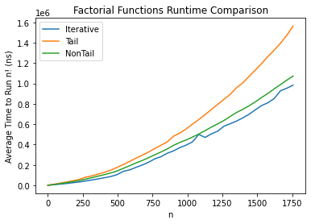

```python
runtime_result_dictionary=compare_all_factorial_on_sample(800,recursion_test_cases)
```

### Comparison Discussion

Interestingly the tail factorial function seemed to have run worsefor these values and appears to perform worse as n grows. The graphs are primarily linear supporting the complexity analysis discussed earlier.

## Part 3: Search Methods

In this section we will the test sequence generated in task 2 using one of our functions as an input for search algorithms, namely two methods from: linear search, iterative binary and recursive binary.

Note: This question is worded poorly so I've no idea what set it means. I returned the time array assuming that, but have heard different info on whether it should be the time set, the test set, or a factorial version of the test set. As the test set is already a sorted array, I'm using this.

My test set for the remainder of this is: [1,46,91,136,181,226,271,316,361,406,451,496,541,586,631,676,721,766,811,856,901,946,991,1036,1081,1126,1171,1216,1261,1306,1351,1396,1441,1486,1531,1576,1621,1666,1711,1756] factorialed

```python
sample=[1,46,91,136,181,226,271,316,361,406,451,496,541,586,631,676,721,766,811,856,901,946,991,1036,1081,1126,1171,1216,1261,1306,1351,1396,1441,1486,1531,1576,1621,1666,1711,1756]
search_set=[]
search_set+=[iterative_factorial(x) for x in sample]
```

## Searches

### Algorithm

#### Binary Search

The algorithm is:

Step 0: Assuming function is passed a sorted array list and an element search_item

Step 1: Set min=0, max=len(array)

Step 2: Get midpoint.

Step 3: If search_item > midpoint, it's in upper half so set min=midpoint. Otherwise in lowerhalf so set max=uppder half.

Step 4: Repeat as long as min/>max.

### Pseudocode

#### binary_search

```
def binary_search(sorted_array,element)
    INPUT:sorted_array,element
```

```
OUTPUT: -1 or i of sorted_array st sorted_array[i]=element

min=0
max=len(sorted_array)


while min<=max
    mid=(max+mid)/2

      if sorted_array[mid] < element
          min=mid+1

      elif sorted_array[mid]>element
            max=mid+1

       else
            return mid


 else
    return -1
```

```python
def binary_search(sorted_array,element):
    """A function to return index of element"""

    min_element=0
    max_element=len(sorted_array)-1

    #While they're not equal
    while min_element<=max_element:

        #Get midpoint
        midpoint=(min_element + max_element) // 2

        #Check which half it's in

        #Mid element less than element -> In Upper half
        if sorted_array[midpoint] < element:
            min_element=midpoint+1

        #Mid element greater than element -> In Lower half
        elif sorted_array[midpoint]>element:
            max_element=midpoint-1

        #Equal
        else:
            return midpoint

    return -1
```

### Complexity Analysis

```
def binary_search(sorted_array,element):
    """A function to return index of element"""
```

After 0 iteration: n elements to search

After 1 iteration: $2^{-1} n$ elements to search

After k iteration: $2^{-k} n$ elements to search

The sequence of elements to search is a strictly monotonic decreasing sequence and is bounded by 1. Hence the iteration count is bounded by $x \text{ iterations}: 2^{-x}=1$

Hence

$2^{-x}=1 \implies n=2^x \implies x = log_2 (n) \implies T(bs(n)) \propto log(n)$

Hence we see T(binary_search) = $\mathcal{O}(log(n))$

## Searches

### Algorithm

#### Linear Search

The algorithm is:

Step 0: for index in 0 to len(array) check if array(index)=element.

### Pseudocode

#### linear_search

```
def linear_search(sorted_array,element)
    INPUT:sorted_array,element
```

```
OUTPUT: -1 or i of sorted_array st sorted_array[i]=element

min=0


for c in range 0 to length of array:
    if array[c]==element
    return c

 return -1
```

```python
def linear_search(sorted_array,element):
    """Searches function from beginning to end

    Returns -1 if not found or otherwise element index"""

    #start from beginning to end
    for index in range(len(sorted_array)):

        #check if element
        if sorted_array[index]==element:
            return index

    return -1
```

### Complexity Analysis

After 0 iteration: n elements to search

After 1 iteration: $n-1$ elements to search

After k iteration: $n-k$ elements to search

After n-n iteration: n elements to search

The sequence of elements to search is a strictly monotonic decreasing sequence and is bounded by 0. Hence the iteration count is bounded by n$

Hence

$T(ls(n)) \propto n$

Hence we see T(linear_search) = $\mathcal{O}(n)$

### After creating these, it makes no sense at all to run these over a list of a static size? Surely it has to be an array of length(n) which is variable? Therefore I am going to generate a multi-array unrelated to part 1.

### Part 4: Sampling and Graphing Search Methods

```python
test_array=[]
sample_v2=[100*x for x in sample]

for x in sample:
    sub_array=[]
    for k in range(x):
        sub_array+=[x]

    test_array+=[sub_array]

test_array_v2=[]
for x in sample_v2:
    sub_array_v2=[]
    for k in range(x):
        sub_array_v2+=[x]

    test_array_v2+=[sub_array_v2]
```

### Best and worst case for linear search and binary search

```python
def ls_best_case(sample_set):
    """Best case of it is always the first element"""
    try:
        return sample_set[0]

    except Exception as e:
        print(e)

def ls_worst_case(sample_set):
    """Worst case of it is always not in the set"""
    return -1
```

```python
def bs_best_case(sample_set):
    """Best case of it is always the first selection element"""
    try:
        return sample_set[(0 + len(sample_set)-1) // 2]

    except Exception as e:
        print(e)

def bs_worst_case(sample_set):
    """Worst case of it is always the first element"""
    return -1
```

### Best case for binary search runtime

```python
def return_bs_runtime_sample_bestcase(number_of_time_to_run,test_multiarray):
    """
    Runs the search function over a test set a number of times.
    """

    #Empty Dictionary
    run_time_amounts={}

    #For each run less than the highest
    for run in range(1,number_of_time_to_run):

        #Clear from previous run
        time_array=[]

        #Starts at first element
        for simple_set in test_multiarray:

            #wipe these variables
            time_start=0
            time_end=0

            #best_case
            bs=bs_best_case(simple_set)

            #Start Timer
            time_start=time.perf_counter_ns()

            #Tail Factorial
            binary_search(simple_set,bs)

            #End timer
            time_end=time.perf_counter_ns()

            #Get delta
            time_delta=time_end-time_start

            #Save to array
            time_array+=[time_delta]

        #Add to dictionary. Key is the number of the run
        run_time_amounts[run]=time_array

    return run_time_amounts
```

### Worst case for binary search runtime

```python
def return_bs_runtime_sample_worstcase(number_of_time_to_run,test_multiarray):
    """
    Runs the search function over a test set a number of times.
    """

    #Empty Dictionary
    run_time_amounts={}

    #For each run less than the highest
    for run in range(1,number_of_time_to_run):

        #Clear from previous run
        time_array=[]

        #Starts at first element
        for simple_set in test_multiarray:

            #wipe these variables
            time_start=0
            time_end=0

            #worst_case
            bs=bs_worst_case(simple_set)

            #Start Timer
            time_start=time.perf_counter_ns()

            #Tail Factorial
            binary_search(simple_set,bs)

            #End timer
            time_end=time.perf_counter_ns()

            #Get delta
            time_delta=time_end-time_start

            #Save to array
            time_array+=[time_delta]

        #Add to dictionary. Key is the number of the run
        run_time_amounts[run]=time_array

    return run_time_amounts
```

### Best for linear search runtime

```python
def return_ls_runtime_sample_bestcase(number_of_time_to_run,test_multiarray):
    """
    Runs the search function over a test set a number of times.
    """

    #Empty Dictionary
    run_time_amounts={}

    #For each run less than the highest
    for run in range(1,number_of_time_to_run):

        #Clear from previous run
        time_array=[]

        #Starts at first element
        for simple_set in test_multiarray:

            #wipe these variables
            time_start=0
            time_end=0

            #best_case
            ls=ls_best_case(simple_set)

            #Start Timer
            time_start=time.perf_counter_ns()

            #Tail Factorial
            linear_search(simple_set,ls)

            #End timer
            time_end=time.perf_counter_ns()

            #Get delta
            time_delta=time_end-time_start

            #Save to array
            time_array+=[time_delta]

        #Add to dictionary. Key is the number of the run
        run_time_amounts[run]=time_array

    return run_time_amounts
```

### Worst case for Linear Search runtime

```python
def return_ls_runtime_sample_worstcase(number_of_time_to_run,test_multiarray):
    """
    Runs the search function over a test set a number of times.
    """

    #Empty Dictionary
    run_time_amounts={}

    #For each run less than the highest
    for run in range(1,number_of_time_to_run):

        #Clear from previous run
        time_array=[]

        #Starts at first element
        for simple_set in test_multiarray:

            #wipe these variables
            time_start=0
            time_end=0

            #best_case
            ls=ls_worst_case(simple_set)

            #Start Timer
            time_start=time.perf_counter_ns()

            #Tail Factorial
            linear_search(simple_set,ls)

            #End timer
            time_end=time.perf_counter_ns()

            #Get delta
            time_delta=time_end-time_start

            #Save to array
            time_array+=[time_delta]

        #Add to dictionary. Key is the number of the run
        run_time_amounts[run]=time_array

    return run_time_amounts
```

### Plot the runtimes on a single graph

```python
def plot_sample_search_runtimes(ls_worst,ls_best,bs_worst,bs_best,array_sizes):
    """Plot the search sample runtimes

    Input: Average time array, Titles, Whether to include the line of best fit
    Returned: Plot
    """

    X = np.array(array_sizes)
    Y_ls_worst = np.array(ls_worst)
    Y_ls_best = np.array(ls_best)
    Y_bs_worst = np.array(bs_worst)
    Y_bs_best = np.array(bs_best)


    #Plot the X and Y arrays
    plt.plot(X,Y_ls_worst,label='LS_Worst')
    plt.plot(X,Y_ls_best,label='LS_Best')
    plt.plot(X,Y_bs_worst,label='BS_Worst')
    plt.plot(X,Y_bs_best,label='BS_Best')

    title='Search Functions Best and Worst Runtime Comparison'
    x_axis_title='Array Size'
    y_axis_title='Average Time to Run Search (ns)'


    #Set the formatting stuff
    plt.title(title)
    plt.ylabel(y_axis_title)
    plt.xlabel(x_axis_title)

    plt.legend()

    #Save in the local directory
    plt.savefig('Search_Function_Comparison.png')

    return
```

```python
def plot_sample_search_runtimes_ls(ls_worst,ls_best,array_sizes):
    """Plot the Linear Search sample runtimes

    Input: Average time array, Titles, Whether to include the line of best fit
    Returned: Plot
    """

    X = np.array(array_sizes)
    Y_ls_worst = np.array(ls_worst)
    Y_ls_best = np.array(ls_best)


    #Plot the X and Y arrays
    plt.plot(X,Y_ls_worst,label='LS_Worst')
    plt.plot(X,Y_ls_best,label='LS_Best')

    title='Search Functions Best and Worst Runtime Comparison'
    x_axis_title='Array Size'
    y_axis_title='Average Time to Run Search (ns)'


    #Set the formatting stuff
    plt.title(title)
    plt.ylabel(y_axis_title)
    plt.xlabel(x_axis_title)

    plt.legend()

    #Save in the local directory
    plt.savefig('Linear_Search_Function_Comparison.png')

    return
```

```python
def plot_sample_search_runtimes_bs(bs_worst,bs_best,array_sizes):
    """Plot the binary search sample runtimes

    Input: Average time array, Titles, Whether to include the line of best fit
    Returned: Plot
    """

    X = np.array(array_sizes)
    Y_bs_worst = np.array(bs_worst)
    Y_bs_best = np.array(bs_best)


    #Plot the X and Y arrays
    plt.plot(X,Y_bs_worst,label='BS_Worst')
    plt.plot(X,Y_bs_best,label='BS_Best')

    title='Search Functions Best and Worst Runtime Comparison'
    x_axis_title='Array Size'
    y_axis_title='Average Time to Run Search (ns)'


    #Set the formatting stuff
    plt.title(title)
    plt.ylabel(y_axis_title)
    plt.xlabel(x_axis_title)

    plt.legend()

    #Save in the local directory
    plt.savefig('Binary_Search_Function_Comparison.png')

    return
```

```python
def compare_search_on_sample(number_of_time_to_run,test_set,array_sizes):
    """A wrapper function to graph the functions against each other"""


    #Run each of the times
    ls_worst=return_ls_runtime_sample_worstcase(number_of_time_to_run,test_set)
    ls_best=return_ls_runtime_sample_bestcase(number_of_time_to_run,test_set)

    bs_worst=return_bs_runtime_sample_worstcase(number_of_time_to_run,test_set)
    bs_best=return_bs_runtime_sample_bestcase(number_of_time_to_run,test_set)


    #Get the mean for each n! in the test set
    mean_array_ls_worst=get_mean_runtime(ls_worst)
    mean_array_ls_best=get_mean_runtime(ls_best)

    mean_array_bs_worst=get_mean_runtime(bs_worst)
    mean_array_bs_best=get_mean_runtime(bs_best)


    #Plot this
    plot_sample_search_runtimes(ls_worst=mean_array_ls_worst
                                ,ls_best=mean_array_ls_best
                                ,bs_worst=mean_array_bs_worst
                                ,bs_best=mean_array_bs_best
                                ,array_sizes=array_sizes)

    #Return the runtimes for Q3?

    return (mean_array_ls_worst,mean_array_ls_best,mean_array_bs_worst,mean_array_bs_best)
```

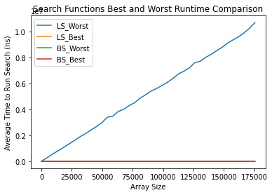

```python
runtimes_search=compare_search_on_sample(500,test_array_v2,sample_v2)
```

```python
def compare_search_on_sample_ls(number_of_time_to_run,test_set,array_sizes):
    """A wrapper function to graph the ls functions against each other"""


    #Run each of the times
    ls_worst=return_ls_runtime_sample_worstcase(number_of_time_to_run,test_set)
    ls_best=return_ls_runtime_sample_bestcase(number_of_time_to_run,test_set)


    #Get the mean for each n! in the test set
    mean_array_ls_worst=get_mean_runtime(ls_worst)
    mean_array_ls_best=get_mean_runtime(ls_best)


    plot_sample_search_runtimes_ls(ls_worst=mean_array_ls_worst
                                ,ls_best=mean_array_ls_best
                                ,array_sizes=array_sizes)
    #Return the runtimes for Q3?

    return (mean_array_ls_worst,mean_array_ls_best)
```

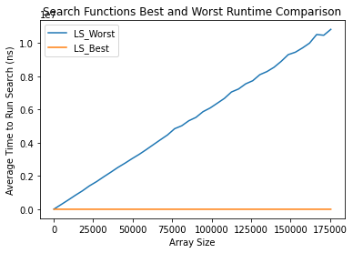

```python
runtimes_ls=compare_search_on_sample_ls(500,test_array_v2,sample_v2)
```

```python
def compare_search_on_sample_bs(number_of_time_to_run,test_set,array_sizes):
    """A wrapper function to graph the bs functions against each other"""


    #Run each of the times
    bs_worst=return_bs_runtime_sample_worstcase(number_of_time_to_run,test_set)
    bs_best=return_bs_runtime_sample_bestcase(number_of_time_to_run,test_set)


    #Get the mean for each n! in the test set
    mean_array_bs_worst=get_mean_runtime(bs_worst)
    mean_array_bs_best=get_mean_runtime(bs_best)


    plot_sample_search_runtimes_bs(bs_worst=mean_array_bs_worst
                                ,bs_best=mean_array_bs_best
                                ,array_sizes=array_sizes)
    #Return the runtimes for Q3?

    return (mean_array_bs_worst,mean_array_bs_best)
```

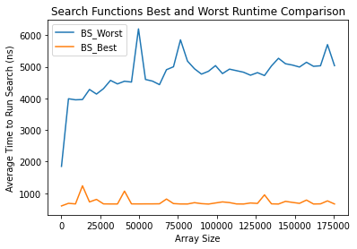

```python
runtimes_bs=compare_search_on_sample_bs(500,test_array_v2,sample_v2)
```

### Discussion

We see that the best case for binary search O(1) (as expected; it's the first search) and worst case is logarithmic.

Similarly we see that the best case for linear search is O(1) while the worst case is linear. Hence we need to plot on separate graphs for a meaningful distinction.

## Part 5:

For the curve plotting, we have the following graphs and best fit lines to produce:

1. Iterative Factorial
2. Tail Factorial
3. NonTail Factorial
4. Best Case Linear Search
5. Worst Case Linear Search
6. Best Case Binary Search
7. Worst Case Binary Search

Thankfully if you've ran everything up until now the data for these is all in memory.

```python
recursive_xaxis_values=sample

iter_times=get_mean_runtime(runtime_result_dictionary[0])
nontail_times=get_mean_runtime(runtime_result_dictionary[1])
tail_times=get_mean_runtime(runtime_result_dictionary[2])

search_xaxis_values=sample_v2

ls_worst_times=runtimes_ls[0]
ls_best_times=runtimes_ls[1]

bs_worst_times=runtimes_bs[0]
bs_best_times=runtimes_bs[1]
```

```python
#Curve Fit on Linear Movels
```

```python
#Based on : https://machinelearningmastery.com/curve-fitting-with-python/

def plot_linear(x_list,y_list,header,xaxis_title):
    """Plot linear function"""

    # define the true distribution

    def match(x, slope, c):
        return (slope * x) + c

    x=np.array(x_list)
    y=np.array(y_list)

    #Match Cyrve
    popt, _ = curve_fit(match, x, y)

    # summarize the parameter values
    slope, c = popt

    print(popt)

    # plot input vs output
    plt.scatter(x, y)

    # define a sequence of inputs between the smallest and largest known inputs
    x_line = np.arange(min(x), max(x), 1)

    # calculate the output for the range
    y_line = match(x_line,slope, c)

    # create a line plot for the mapping function
    plt.plot(x_line, y_line, '--', color='red',label=f'y={slope}x+{c}')

    plt.title(header)
    plt.ylabel('Average running time (ns)')
    plt.xlabel(xaxis_title)
    plt.legend()

    plt.show()
    file_name=f"{header}.png"
    plt.savefig(file_name)
```

```python
linear=[
    [iter_times,'Iterative Factorial','n!',recursive_xaxis_values]
    ,[nontail_times,'NonTail Factorial','n!',recursive_xaxis_values]
    ,[tail_times,'Tail Factorial','n!',recursive_xaxis_values]
    ,[ls_worst_times,'Linear Search Worst','n!',search_xaxis_values]
    ,[ls_best_times,'Linear Search Best','n!',search_xaxis_values]
    ,[bs_best_times,'Binary Search Best','n!',search_xaxis_values]
]

log=[
    [bs_worst_times,'Binary Search Worst','n!',search_xaxis_values]
]
```

### Loop Through them and output

```
[    576.23098288 -130440.94028676]
```

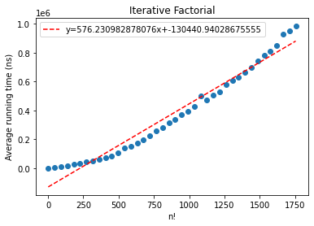

```
None
```

```
[    624.53543798 -125149.49547224]
```

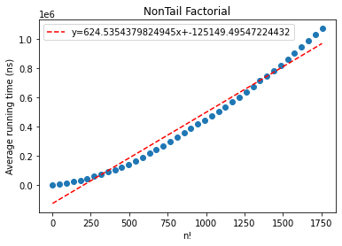

```
None
```

```
[    875.31073546 -204599.10749802]
```

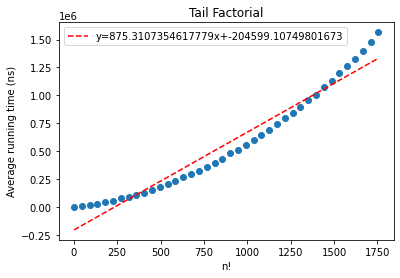

```
None
```

```
[   61.90144311 -5104.34810379]
```

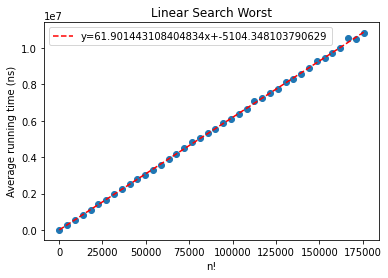

```
None
```

```
[1.04123943e-04 6.54845898e+02]
```

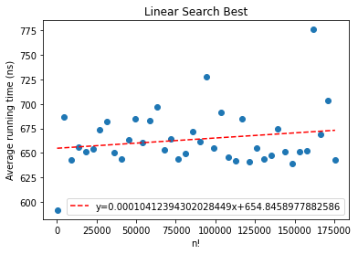

```
None
```

```
[-3.15856230e-04  7.44808891e+02]
```

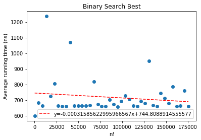

```
None
```

```python
for fit_model in linear:
    display(plot_linear(x_list=fit_model[3],y_list=fit_model[0],header=fit_model[1],xaxis_title=fit_model[2]))
```

## Chart the final non-linear model

```python
#Based on : https://machinelearningmastery.com/curve-fitting-with-python/

def plot_log(x_list,y_list,header,xaxis_title):
    """Plot linear function"""

    # define the true distribution

    def match(x, a, b, c):
        return a * np.log2(b * x) + c

    x=np.array(x_list)
    y=np.array(y_list)

    #Match Cyrve
    popt, _ = curve_fit(match, x, y)

    # summarize the parameter values
    a,b,c = popt

    print(popt)

    # plot input vs output
    plt.scatter(x, y)

    # define a sequence of inputs between the smallest and largest known inputs
    x_line = np.arange(min(x), max(x), 1)

    # calculate the output for the range
    y_line = match(x_line,  a, b, c)

    # create a line plot for the mapping function
    plt.plot(x_line, y_line, '--', color='red',label=f'y={a} * np.log({b} * x) + {c}')

    plt.title(header)
    plt.ylabel('Average running time (ns)')
    plt.xlabel(xaxis_title)
    plt.legend()

    plt.show()
    file_name=f"{header}.png"
    plt.savefig(file_name)
```

```
[  290.75028889    82.70596022 -1711.16807706]
```

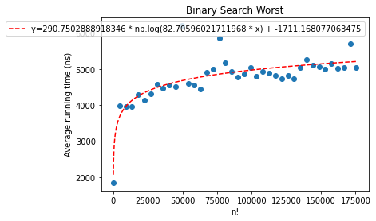

```
None
```

```python
for fit_model in log:
    display(plot_log(x_list=fit_model[3],y_list=fit_model[0],header=fit_model[1],xaxis_title=fit_model[2]))
```